# MTHM_505

- Based on the plot we have choosen **nugget value as 150**.

```r
vari.default1 <- variofit(sample_vario,nugget = 150,fix.nugget = TRUE)
```

```
## variofit: covariance model used is matern
## variofit: weights used: npairs
## variofit: minimisation function used: optim
## variofit: searching for best initial value ... selected values:
##               sigmasq   phi    tausq kappa
## initial.value "1742.63" "1.54" "150" "0.5"
## status        "est"     "est"  "fix" "fix"
## loss value: 168233561.969697
```

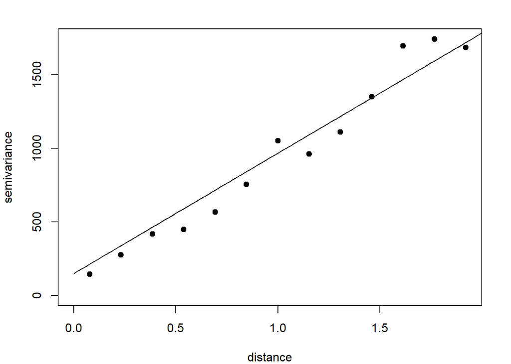

```r
par(mar=c(4,4,2,2))
plot(sample_vario, pch = 19)
lines(vari.default1)
```

```r
vari.default2 <- variofit(sample_vario,nugget = 150,fix.nugget = TRUE,cov.model = 'gaussian')
```

```
## variofit: covariance model used is gaussian
## variofit: weights used: npairs
## variofit: minimisation function used: optim
## variofit: searching for best initial value ... selected values:
##               sigmasq   phi    tausq kappa
## initial.value "1742.63" "1.23" "150" "0.5"
## status        "est"     "est"  "fix" "fix"
## loss value: 51234686.7662128
```

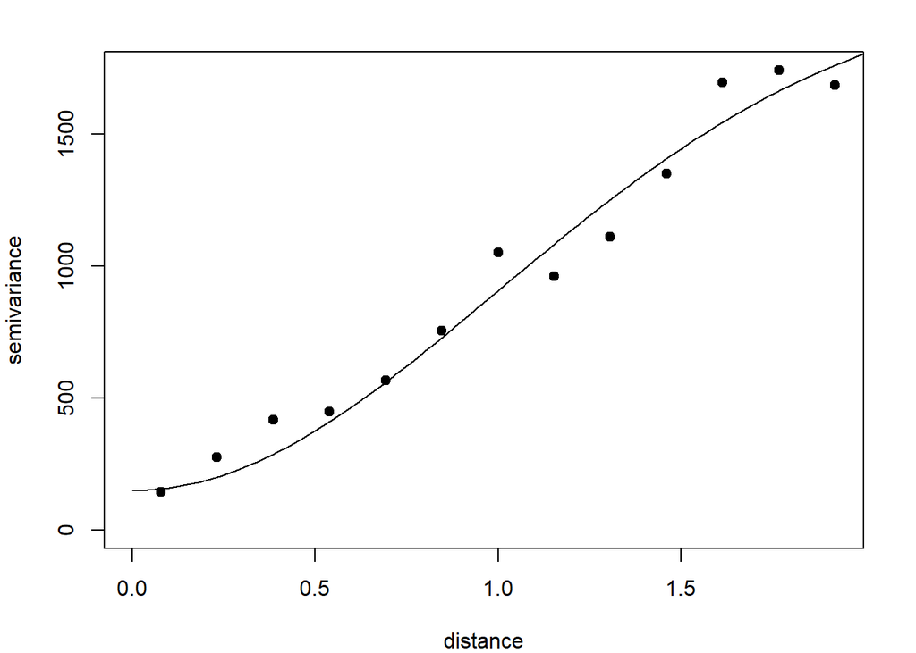

```r
par(mar=c(4,4,2,2))
plot(sample_vario, pch = 19)
lines(vari.default2)
```

```r
vari.default3 <- variofit(sample_vario,nugget = 150,fix.nugget = TRUE,cov.model = 'exponential')
```

```
## variofit: covariance model used is exponential
## variofit: weights used: npairs
## variofit: minimisation function used: optim
## variofit: searching for best initial value ... selected values:
##               sigmasq   phi    tausq kappa
## initial.value "1742.63" "1.54" "150" "0.5"
## status        "est"     "est"  "fix" "fix"
## loss value: 168233561.969697
```

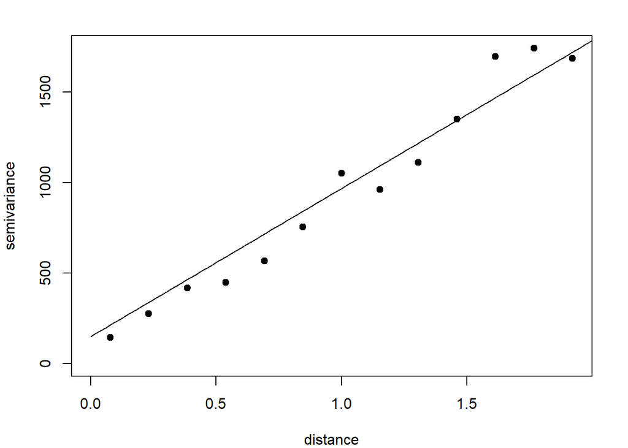

```r
par(mar=c(4,4,2,2))
plot(sample_vario, pch = 19)
lines(vari.default3)
```

```r
vari.default4 <- variofit(sample_vario,nugget = 150,fix.nugget = TRUE,cov.model = 'spherical')
```

```
## variofit: covariance model used is spherical
## variofit: weights used: npairs
## variofit: minimisation function used: optim
## variofit: searching for best initial value ... selected values:
##               sigmasq   phi    tausq kappa
## initial.value "1306.98" "1.54" "150" "0.5"
## status        "est"     "est"  "fix" "fix"
## loss value: 319180541.33932
```

[figure not shown]

```r
par(mar=c(4,4,2,2))
plot(sample_vario, pch = 19)
lines(vari.default4)
```

- After experimenting with various assumptions of the variofit function, ranging from “matern” to “exponential”, and setting the nugget value to 150, I determined that the *Gaussian model* was the best fit model (vario.default2) by analyzing the weighted least square values of each model.

- I kept the mean/trend values *constant* since setting them as “1st” or “2nd” order resulted in a *sigmasq value of zero (0)*.

```r
xv.ml <- xvalid(train_data, model = vari.default2)
```

```
## xvalid: number of data locations       = 95
## xvalid: number of validation locations = 95
## xvalid: performing cross-validation at location ... 1, 2, 3, 4, 5, 6, 7, 8, 9, 10, 11, 12, 13, 14, 15, 16, 17, 18, 19, 20, 21, 22, 23, 24, 25, 26, 27, 28, 29, 30, 31, 32, 33, 34, 35, 36, 37, 38, 39, 40, 41, 42, 43, 44, 45, 46, 47, 48, 49, 50, 51, 52, 53, 54, 55, 56, 57, 58, 59, 60, 61, 62, 63, 64…
## xvalid: end of cross-validation
```

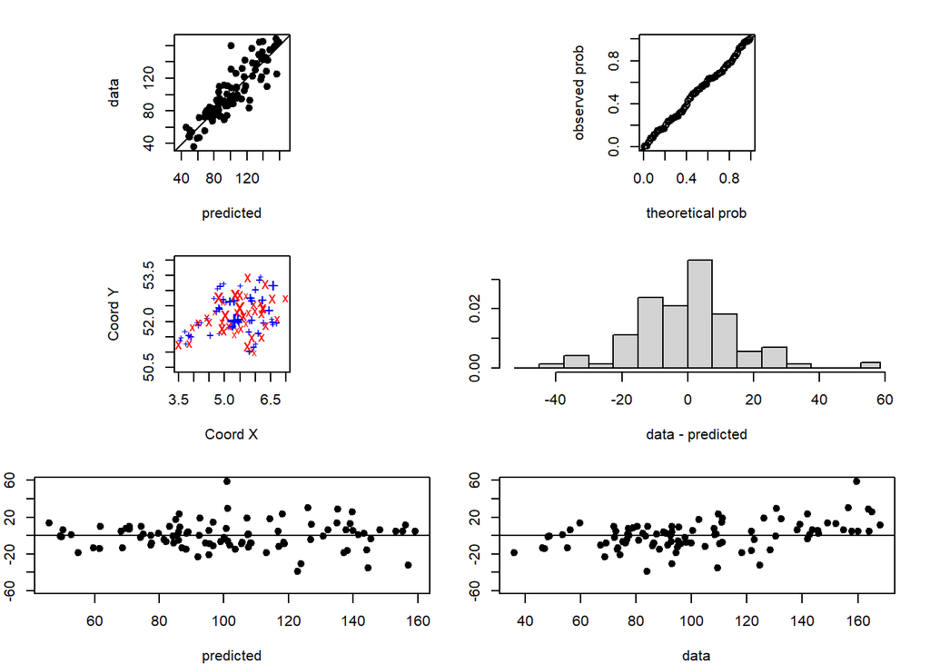

```r
par(mfrow=c(3,2),mar=c(4,2,2,2))
plot(xv.ml, error = TRUE, std.error = FALSE, pch = 19)
```

- We see that there is a relatively strong relationship between the fitted and true values (top left).

- The histogram plot shows a normal distribution.
- The residual plots have some kind of similar pattern this suggests the good model fit.

# 1)d)

```r
vari.default2$cov.pars
```

```
## [1] 1906.579522    1.406202
```

```r
model_ml0 <- likfit(train_data,ini.cov.pars = c(1742.63, 1.23), cov.model = 'spherical')
```

```
## kappa not used for the spherical correlation function
## ---------------------------------------------------------------
## likfit: likelihood maximisation using the function optim.
## likfit: Use control() to pass additional
##          arguments for the maximisation function.
##         For further details see documentation for optim.
## likfit: It is highly advisable to run this function several
##         times with different initial values for the parameters.
## likfit: WARNING: This step can be time demanding!
## ---------------------------------------------------------------
## likfit: end of numerical maximisation.
```

```r
model_ml0
```

```
## likfit: estimated model parameters:
##       beta      tausq    sigmasq        phi
## " 101.922" "  68.892" "1481.496" "   3.401"
## Practical Range with cor=0.05 for asymptotic range: 3.400501
##
## likfit: maximised log-likelihood = -400.1
```

```r
xv.ml3 <- xvalid(train_data, model = model_ml0)
```

```
## xvalid: number of data locations       = 95
## xvalid: number of validation locations = 95
## xvalid: performing cross-validation at location ... 1, 2, 3, 4, 5, 6, 7, 8, 9, 10, 11, 12, 13, 14, 15, 16, 17, 18, 19, 20, 21, 22, 23, 24, 25, 26, 27, 28, 29, 30, 31, 32, 33, 34, 35, 36, 37, 38, 39, 40, 41, 42, 43, 44, 45, 46, 47, 48, 49, 50, 51, 52, 53, 54, 55, 56, 57, 58, 59, 60, 61, 62, 63, 64…
## xvalid: end of cross-validation
```

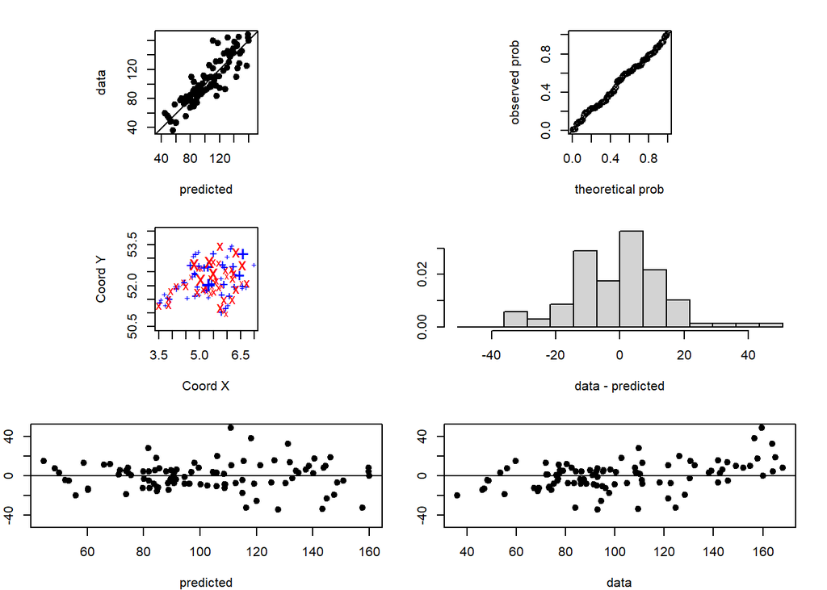

```r
par(mfrow=c(3,2),mar=c(4,2,2,2))
plot(xv.ml3, error = TRUE, std.error = FALSE, pch = 19)
```

```r
gp_model <- likfit(train_data, cov.model = "spherical", nugget = 150, ini.cov.pars = c(300, 1), fix.nugget = TRUE)
```

```
## kappa not used for the spherical correlation function
## ---------------------------------------------------------------
## likfit: likelihood maximisation using the function optim.
## likfit: Use control() to pass additional
##          arguments for the maximisation function.
##         For further details see documentation for optim.
## likfit: It is highly advisable to run this function several
##         times with different initial values for the parameters.
## likfit: WARNING: This step can be time demanding!
## ---------------------------------------------------------------
## likfit: end of numerical maximisation.
```

```r
gp_model
```

```
## likfit: estimated model parameters:
##       beta    sigmasq        phi
## " 101.096" "1240.170" "   4.977"
## Practical Range with cor=0.05 for asymptotic range: 4.976687
##
## likfit: maximised log-likelihood = -401.3
```

```r
xv.ml00 <- xvalid(train_data, model = gp_model)
```

```
## xvalid: number of data locations       = 95
## xvalid: number of validation locations = 95
## xvalid: performing cross-validation at location ... 1, 2, 3, 4, 5, 6, 7, 8, 9, 10, 11, 12, 13, 14, 15, 16, 17, 18, 19, 20, 21, 22, 23, 24, 25, 26, 27, 28, 29, 30, 31, 32, 33, 34, 35, 36, 37, 38, 39, 40, 41, 42, 43, 44, 45, 46, 47, 48, 49, 50, 51, 52, 53, 54, 55, 56, 57, 58, 59, 60, 61, 62, 63, 64…
## xvalid: end of cross-validation
```

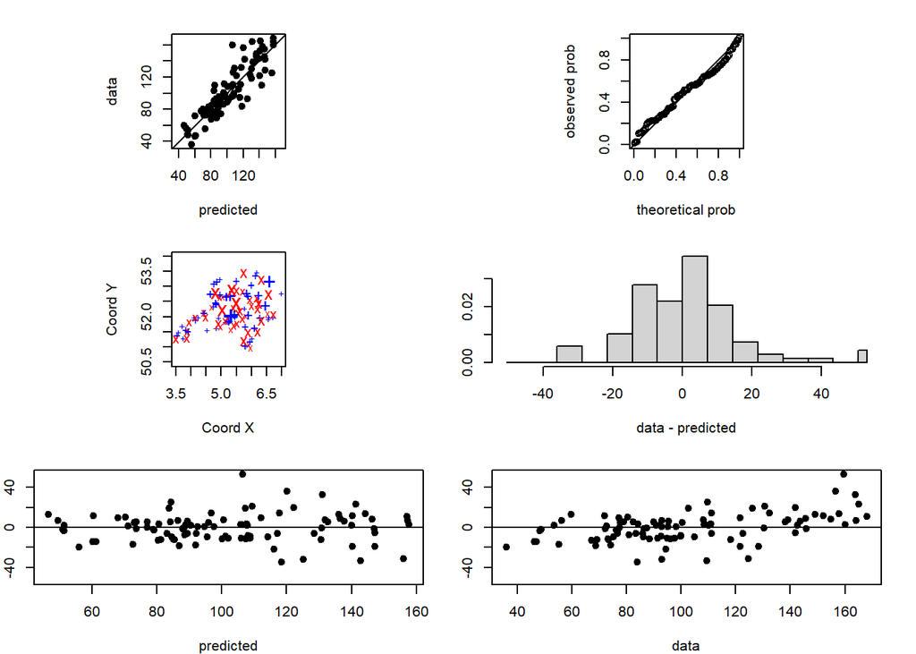

```r
par(mfrow=c(3,2),mar=c(4,2,2,2))
plot(xv.ml00, error = TRUE, std.error = FALSE, pch = 19)
```

```r
model_trend0 <- likfit(train_data, trend = '1st', ini.cov.pars = c(1742.63, 1.23), cov.model = 'matern',kappa = 5/2)
```

```
## ---------------------------------------------------------------
## likfit: likelihood maximisation using the function optim.
## likfit: Use control() to pass additional
##          arguments for the maximisation function.
##         For further details see documentation for optim.
## likfit: It is highly advisable to run this function several
##         times with different initial values for the parameters.
## likfit: WARNING: This step can be time demanding!
## ---------------------------------------------------------------
## likfit: end of numerical maximisation.
```